# Bi Weekly Assignment- Write a story with visualization

Shyni David

1/9/2019

**Dataset - Video Games Sales with Ratings**  
*Name* - Name of the game  
*Platform* - Console on which the game is running  
*Year_of_Release* - Year of the game released  
*Genre* - Games category  
*Publisher* - Publisher  
*NA_Sales* - Games sales in North America (in millions of units)  
*EU_Sales* - Games sales in European Union (in millions of units)  
*JP_Sales* - Games sales in Japan (in millions of units)  
*Other_States* - Games sales in Africa, Asia excluding EU and SouthAmerica (in millions of units)  
*Global_Sales* - Total Sales in the world (in millions of unit)  
*Critic_Score* - Aggregate score compiled by Metacritic staff  
*Critic_Count* - The number of critics used in coming up with the Crtic_Score  
*User_Score* - Scores by Metacritics subscribers  
*User_Count* - Number of users who gave the User_Score  
*Developer* - Party responsible for creating the game  
*Rating* - The ESRB(Entertainment Software Rating Board , ratings are EC-early childhood, E-everyone, E10+(everyone 10+, T-teen, M-mature, AO- adult only)

```r
#install.packages("tidyverse")
library(tidyverse)
library(ggplot2)
library(sqldf)
df <- read_csv("/Users/shynidavid/Desktop/Desktop/FISHER SMB-A/Term 3/Descriptive Analytics/Week 1/Video_Games_Sales_as_at_22_Dec_2016.csv")
glimpse(df)
```

```
## Observations: 16,719
## Variables: 16
## $ Name            <chr> "Wii Sports", "Super Mario Bros.", "Mario Kart...
## $ Platform        <chr> "Wii", "NES", "Wii", "Wii", "GB", "GB", "DS", ...
## $ Year_of_Release <chr> "2006", "1985", "2008", "2009", "1996", "1989"...
## $ Genre           <chr> "Sports", "Platform", "Racing", "Sports", "Rol...
## $ Publisher       <chr> "Nintendo", "Nintendo", "Nintendo", "Nintendo"...
## $ NA_Sales        <dbl> 41.36, 29.08, 15.68, 15.61, 11.27, 23.20, 11.2...
## $ EU_Sales        <dbl> 28.96, 3.58, 12.76, 10.93, 8.89, 2.26, 9.14, 9...
## $ JP_Sales        <dbl> 3.77, 6.81, 3.79, 3.28, 10.22, 4.22, 6.50, 2.9...
## $ Other_Sales     <dbl> 8.45, 0.77, 3.29, 2.95, 1.00, 0.58, 2.88, 2.84...
## $ Global_Sales    <dbl> 82.53, 40.24, 35.52, 32.77, 31.37, 30.26, 29.8...
## $ Critic_Score    <dbl> 76, NA, 82, 80, NA, NA, 89, 58, 87, NA, NA, 91...
## $ Critic_Count    <dbl> 51, NA, 73, 73, NA, NA, 65, 41, 80, NA, NA, 64...
## $ User_Score      <chr> "8", NA, "8.3", "8", NA, NA, "8.5", "6.6", "8....
## $ User_Count      <dbl> 322, NA, 709, 192, NA, NA, 431, 129, 594, NA, ...
## $ Developer       <chr> "Nintendo", NA, "Nintendo", "Nintendo", NA, NA...
## $ Rating          <chr> "E", NA, "E", "E", NA, NA, "E", "E", "E", NA, ...
```

```r
#to fx data type, NA
df1<- df %>% type_convert(col_types = cols(
  Year_of_Release = col_integer(),
  User_Score = col_double()),
  na = c("N/A", "tbd")
)
summary(df1)
```

```
##      Name             Platform         Year_of_Release    Genre
##  Length:16719       Length:16719       Min.   :1980    Length:16719
##  Class :character   Class :character   1st Qu.:2003    Class :character
##  Mode  :character   Mode  :character   Median :2007    Mode  :character
##                                        Mean   :2006
##                                        3rd Qu.:2010
##                                        Max.   :2020
##                                        NA's   :269
##   Publisher            NA_Sales          EU_Sales         JP_Sales
##  Length:16719       Min.   : 0.0000   Min.   : 0.000   Min.   : 0.0000
##  Class :character   1st Qu.: 0.0000   1st Qu.: 0.000   1st Qu.: 0.0000
##  Mode  :character   Median : 0.0800   Median : 0.020   Median : 0.0000
##                     Mean   : 0.2633   Mean   : 0.145   Mean   : 0.0776
##                     3rd Qu.: 0.2400   3rd Qu.: 0.110   3rd Qu.: 0.0400
##                     Max.   :41.3600   Max.   :28.960   Max.   :10.2200
##
##   Other_Sales        Global_Sales      Critic_Score    Critic_Count
##  Min.   : 0.00000   Min.   : 0.0100   Min.   :13.00   Min.   :  3.00
##  1st Qu.: 0.00000   1st Qu.: 0.0600   1st Qu.:60.00   1st Qu.: 12.00
##  Median : 0.01000   Median : 0.1700   Median :71.00   Median : 21.00
##  Mean   : 0.04733   Mean   : 0.5335   Mean   :68.97   Mean   : 26.36
##  3rd Qu.: 0.03000   3rd Qu.: 0.4700   3rd Qu.:79.00   3rd Qu.: 36.00
##  Max.   :10.57000   Max.   :82.5300   Max.   :98.00   Max.   :113.00
##                                       NA's   :8582    NA's   :8582
##    User_Score      User_Count       Developer            Rating
##  Min.   :0.000   Min.   :    4.0   Length:16719       Length:16719
##  1st Qu.:6.400   1st Qu.:   10.0   Class :character   Class :character
##  Median :7.500   Median :   24.0   Mode  :character   Mode  :character
##  Mean   :7.125   Mean   :  162.2
##  3rd Qu.:8.200   3rd Qu.:   81.0
##  Max.   :9.700   Max.   :10665.0
##  NA's   :9129    NA's   :9129
```

This is a report summary of the Video Games Sales on key aspects.  
First, let’s analyse the Customer Preference of Platform based on ESRB Ratings.

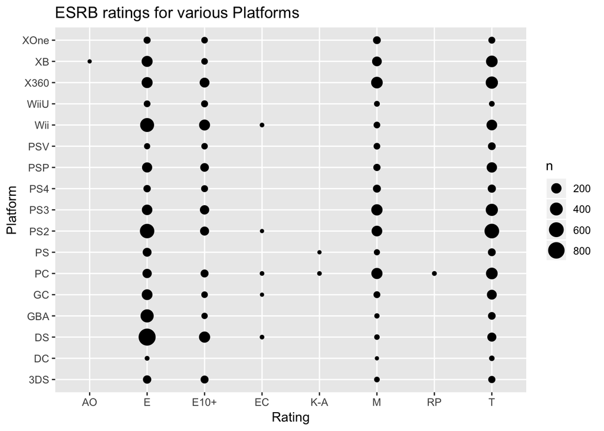

```r
#sqldf("select distinct(rating) from df1")
df2 <- df1 %>% filter(!is.na(Rating))
df2 %>% ggplot(aes(Rating, Platform)) + geom_count() + labs(title = "ESRB ratings for various Platforms")
```

The Platform PS2(Play station 2) was the most popular among Teens. X13, X360, PS3 and PC were Teens other favorites.  
Nintendo DS seemed be to be most favourite among E-Everyone.  
For E10+(Everyone 10+) category, Nintendo DS, Wii and X360 are the notable favorites.  
In E(Everyone) category and across all Ratings, WiiU, PSV, PS4 and DC seemed to be the least favorite.

Let’s explore the variation of the MetaCritic’s score in the Years of Release on various Platforms.

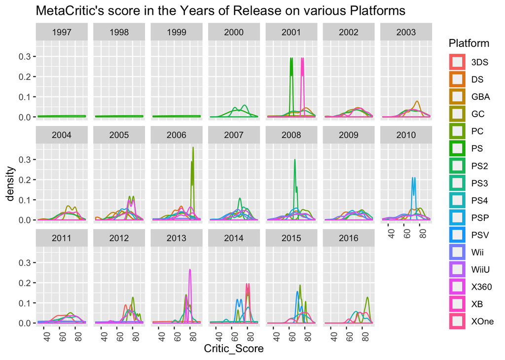

```r
#Removing NA to get better plot as data not available
cust <- sqldf("select * from df1 where Year_of_Release <> 'NA' and Critic_Score  <> 'NA'  ")
cust1<- sqldf("select * from cust where Year_of_Release > 1995 ")
#cust1 %>% ggplot(aes(Critic_Score, color = Platform)) + geom_density(binwidth = 0.09) + facet_wrap(~ Year_of_Release, nrow = 3) + theme(axis.text.x =element_text(angle = 90, hjust=1)) + xlab("MetaCritic's score in the Years of Release on various Platforms")

#to remove groups less than 2 data points
cust2 <- cust1 %>% group_by(Year_of_Release, Platform, Critic_Score) %>% filter(n()>2)

cust2 %>% ggplot(aes(Critic_Score, color = Platform)) + geom_density(binwidth = 0.09) + facet_wrap(~ Year_of_Release, nrow = 3) + theme(axis.text.x =element_text(angle = 90, hjust=1)) + guides(colour = guide_legend(override.aes = list(size=3, alpha = 1))) + labs(title = "MetaCritic's score in the Years of Release on various Platforms")
```

I did some research in Wiki to see if these observations were matching up and here is what I find:  
-in 2001, XBox was launched and quickly sold out.  
-PS was introduced much earlier but 2001 peak was due to the introduction of online gaming.  
-Xbox One was released on Nov 2013  
-June 2010, manufacturer announced PSP Go would be disconnected outside of NA.  
-Late 2013, PC AMD announced Mantle, a low level API with greater performance

```r
#x1 <- sqldf("select * from cust1 where Year_of_Release = 2001")
# sqldf("select count(*) from x1 where Platform = 'X360'")
# x1 %>% group_by(Platform) %>% count()
```

Next, let’s analyse the Sales metrics. For this we need to compare the Sales in North America, Europe, Japan, Other countries and Globally for the Releases.

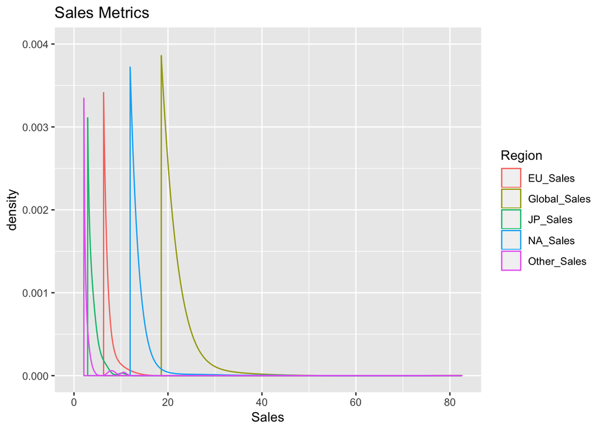

```r
 # have year, Platform , sales, Country
sale <- df1 %>% select(Year_of_Release, Platform, NA_Sales, EU_Sales, JP_Sales, Other_Sales, Global_Sales)
sales1 <- sale %>% gather(key = Region, value = Sales, -Year_of_Release, -Platform)

sales1 %>% ggplot(aes(Sales, color = Region)) + geom_density(adjust = 200) + ylim(0, .004) + labs(title = "Sales Metrics")
```

```r
  #sqldf("select count(*) from sales1 where region = 'NA_Sales' and Sales > 20")
```

Finally, lets also compare the Gamer’s and the Metacritic’s preferences. Metascores range from 0-100, with higher scores indicating better overall reviews. User score is a 10 point score grading.  
a) Games which has high Metascore and low user scores  
b) Games which has low Metascore and high user scores.

```r
score <- sqldf("select Name, Critic_Score, User_Score, Year_of_Release, Platform from df1")
summary(score)
```

```
##      Name            Critic_Score     User_Score    Year_of_Release
##  Length:16719       Min.   :13.00   Min.   :0.000   Min.   :1980
##  Class :character   1st Qu.:60.00   1st Qu.:6.400   1st Qu.:2003
##  Mode  :character   Median :71.00   Median :7.500   Median :2007
##                     Mean   :68.97   Mean   :7.125   Mean   :2006
##                     3rd Qu.:79.00   3rd Qu.:8.200   3rd Qu.:2010
##                     Max.   :98.00   Max.   :9.700   Max.   :2020
##                     NA's   :8582    NA's   :9129    NA's   :269
##    Platform
##  Length:16719
##  Class :character
##  Mode  :character
##
##
##
##
```

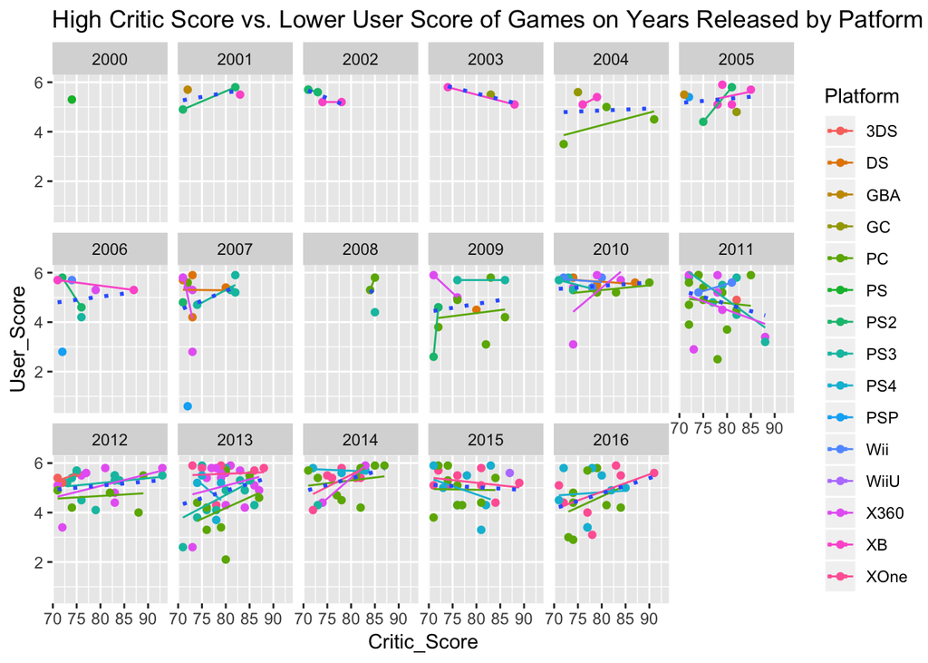

```r
score1 <- score %>% filter(!is.na(Year_of_Release), !is.na(User_Score), !is.na(Critic_Score))
#High Critic Score, lower User score
score2 <- score1 %>% filter(Critic_Score > 70 & User_Score < 6) %>% arrange(desc(Critic_Score))

#score2 %>% ggplot(aes(x = Critic_Score, y = User_Score, color = Platform)) + geom_point() + geom_smooth(aes(group = 1), method = "lm", se = FALSE)  + facet_wrap(~ Year_of_Release, nrow = 3) + labs(title = "High Critic Score vs. Lower User Score")

#score2 %>% select(Platform) %>% group_by(Platform) %>% count() %>% arrange(desc(n))

score2 %>% ggplot(aes(x = Critic_Score, y = User_Score, color = Platform)) + geom_point() + geom_smooth(method = "lm", se = FALSE, size = 0.5) + geom_smooth(aes(group = 1), method = "lm", se = FALSE, linetype = 3)  + facet_wrap(~ Year_of_Release, nrow = 3) + labs(title = "High Critic Score vs. Lower User Score of Games on Years Released by Patform")
```

The dotted lines is the aggregate of all scores for Platforms and we see that Games released mainly on X360, PC, and PS3 is hovering on a range of User Score 5-6 for a high Metascore from 70-90 for Games released over the years. Separate line automatically fit the Platforms.

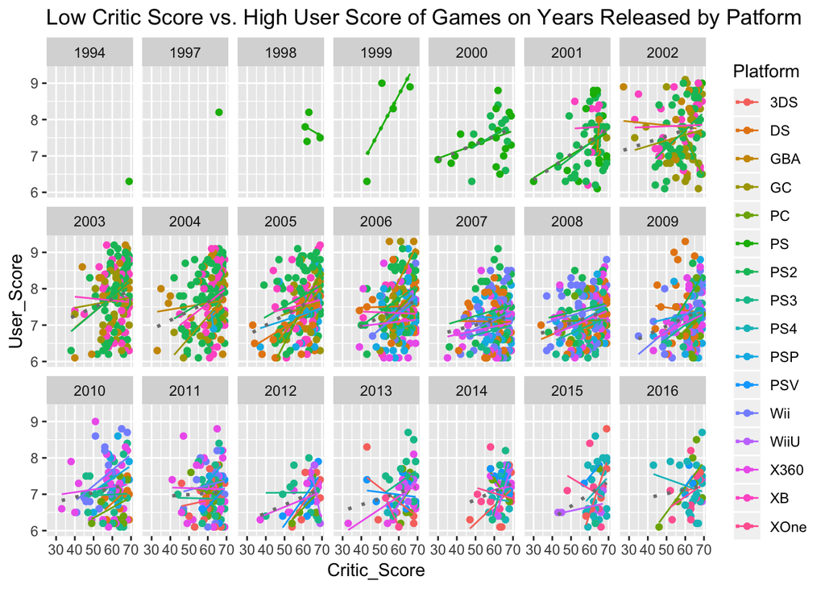

```r
#High User Score, lower Critic score
score3 <- score1 %>% filter(Critic_Score < 70 & User_Score > 6) %>% arrange(desc(Critic_Score))

#score3 %>% ggplot(aes(x = Critic_Score, y = User_Score, color = Platform)) + geom_point() + geom_smooth(aes(group = 1), method = "lm", se = FALSE)  + facet_wrap(~ Year_of_Release, nrow = 3) + labs(title = "High User Score vs. Lower Critic Score")

#score3 %>% select(Platform) %>% group_by(Platform) %>% count() %>% arrange(desc(n))

score3 %>% ggplot(aes(x = Critic_Score, y = User_Score, color = Platform)) + geom_point() + geom_smooth(method = "lm", se = FALSE, size = 0.5) + geom_smooth(aes(group = 1), method = "lm", se = FALSE, linetype = 3)  + facet_wrap(~ Year_of_Release, nrow = 3) + labs(title = "Low Critic Score vs. High User Score of Games on Years Released by Patform")
```

The plot of High User score vs Low Critic score is dense showing that fans of video games have a distinctively different opinion than the game critics!